# Web scraping 1

Advanced Crime Analysis UCL

Bennett Kleinberg

14 Jan 2019

Getting data from the Internet

Webscraping 1

## Today

- Types of webscraping
- Using APIs: Twitter + YouTube
- Crime data ‘wrappers’
- “Real” webscraping: basics of a webpage

## What is webscraping anyway?

## The game changer!

- direct broadcasting of ideas
- “unfiltered” and “uncensored” (?)
- location-enabled
- and: *en masse*

[figure not shown]

## Types of webscraping

|  | Data shared | Data not shared |
| --- | --- | --- |
| Ready-made table | Download | *closed source* |
| Not ready-made | API | Real webscraping |

### Application programming interfaces (APIs)

## API: basics

Goal:

- help developers interact with the platform
- facilitates interaction in an automatable manner
- analogous to the GUI
- part of it: enabling data access
- contains precise documentation

## What an API does not do:

- give you all the data
- be free forever
- give you full control

There’ no free lunch!

## Using an API

Core elements of an API:

- GET requests
- POST requests

Implementable in different ways…

## Using an API

Classes of APIs:

1. Web APIs
   - send requests through the browser
   - add URL parameters `https://data.police.uk/api/crimes-at-location?date=2017-08&location_id=884227`
2. Libraries/packages for APIs
   - depending on the API: python, js, php, ruby
   - = frameworks to access the API
   - = methods implemented in different languages
3. API wrappers
   - R packages that use the API

## Using an API

Identify API capabilities

[Official API docs Twitter](https://developer.twitter.com/en/docs/tweets/search/api-reference)

## Useful websites that have an API

- Twitter
- YouTube
- Instagram
- Facebook
- Reddit

## Case 1: Twitter’s API

[figure not shown]

## Getting access

Basic steps

1. Twitter account
2. Apply for a developer’s account
3. Create project
4. Obtain access credentials

Tutorial [here](https://towardsdatascience.com/access-data-from-twitter-api-using-r-and-or-python-b8ac342d3efe)

```r
library(twitteR)
```

- Documentation: [R Docs](https://www.rdocumentation.org/packages/twitteR/versions/1.1.9)
- Demos: [basic first steps]https://towardsdatascience.com/access-data-from-twitter-api-using-r-and-or-python-b8ac342d3efe) + next week’s tutorial

Note: check out the newer rtweet package.

## Authenitication through R

```r
my_consumer_key = "5tc2oAVLyO8DkCKW1k8ny2H6e"
my_consumer_secret = "qEQYGX6IKs6NiSUsENprBZlOOdoM9lWkoIht3p1sVnAMraQpq2"
my_access_token = "858383409986625537-Fy9Ai5eFyf23VZHguRJEdXqell6Q8Jl"
my_access_secret = "nT5Z0eQjAvBdf2ZjxMgiaoRb7hiHVxB8jYh7lT74CW1Um"

setup_twitter_oauth(consumer_key = my_consumer_key
                    , consumer_secret = my_consumer_secret
                    , access_token = my_access_token
                    , access_secret = my_access_secret
                    )
```

```
## [1] "Using direct authentication"
```

## How to search?

**Remember the problem-solving approach?**

Start with the problem…

…then do what’s necessary to solve it.

*The research question determines the method*

## How to search?

Depends on the problem:

- Tweets in a certain time frame (e.g. December 2018)
- Tweets with a certain key-word (e.g. “#metoo”)
- Tweets by a certain author (e.g. Elon Musk)
- Tweets in a certain location (e.g. London)
- Tweets in a certain language
- Combined search queries

## API possibilities

Always look at two sources:

1. The original API [(Twitter’s API docs)](https://developer.twitter.com/en/docs/tweets/search/api-reference/get-search-tweets.html)
2. The API interface [(`twitteR R package`)](https://www.rdocumentation.org/packages/twitteR/versions/1.1.9)

Note: mostly original API options > API interface options.

## Tweets by date

Search:

- tweets since December 2018
- with `#metoo`

```r
metoo_tweets_december = searchTwitter(searchString = '#metoo'
                                , n = 10
                                , since = '2018-12-01'
                                )
metoo_tweets_december
```

```
## [[1]]
## [1] "zee45427557: #RajkumarHirani @aamir_khan #AamirKhan #aamir #3idiots #pk #MeToo #MeTooMovement #sanju #chopra #joshi https://t.co/76F422oOSM"
##
## [[2]]
## [1] "metoozoo: #MeToo Merch - YellowMaps Beaver Island MI topo map, 1:100000 Scale, 30 X 60 Minute, Historical, 1984, Updated 1989… https://t.co/DsklJ4FZrA"
##
## [[3]]
## [1] "Mirbia3: RT @la_patilla: Los aspirantes demócratas a la Casa Blanca bajo examen del #MeToo https://t.co/DYj2t5OFcS       .     ."
##
## [[4]]
## [1] "gulfkannadiga: RT @timesofindia: #MeToo movement: Filmmaker #RajkummarHirani's Assistant Director  of #Sanju accuses him of sexual harassment \n\nvia @etime…"
##
## [[5]]
## [1] "WeForNews: Rajkumar Hirani accused of sexual assault during making of Sanju\n\n#MeToo #MeTooMovement #RajuBhai #RajKumarHirani… https://t.co/rw3zpitdUd"
##
## [[6]]
## [1] "worldwidetoto10: RT @12ji10pun: 怒りが収まらない\U0001f4a2\n海外では問題になりそうな #松本人志 の発言。\nこのセクハラ発言を寛容で場の雰囲気を壊さないような対応をするのが日本式の「大人でいいオンナ」\n だから #MeToo 運動は日本では無縁。\nなんてったって被害に遭ったメンバーが謝罪…"
##
## [[7]]
## [1] "Neli_Ngqulana: RT @Moosa_Kaula: Are girlies gonna pretend like Arthur Mafokate isn't the face of #MeToo and pose happily with him? \U0001f62c https://t.co/9yMDmDUL…"
##
## [[8]]
## [1] "Rohitpatil_24: RT @NEWS9TWEETS: #BIGNEWS: #Bollywood's famed director, @RajkumarHirani allegedly accused of sexual harassment by an assistant director of…"
##
## [[9]]
## [1] "jackejones123: @keithellison #MeToo"
##
## [[10]]
## [1] "Hun_Aram_e: RT @Bollyhungama: #MeToo: #SANJU director #RajkumarHirani accused of SEXUAL HARASSMENT by his assistant\nhttps://t.co/duGjUEaDI7"
```

## Tweets by date

Display as dataframe with meta information:

```r
twListToDF(metoo_tweets_december)
```

```
##                                                                                                                                                                                                                                                                    text
## 1                                                                                                                                        #RajkumarHirani @aamir_khan #AamirKhan #aamir #3idiots #pk #MeToo #MeTooMovement #sanju #chopra #joshi https://t.co/76F422oOSM
## 2                                                                                                                          #MeToo Merch - YellowMaps Beaver Island MI topo map, 1:100000 Scale, 30 X 60 Minute, Historical, 1984, Updated 1989… https://t.co/DsklJ4FZrA
## 3                                                                                                                                               RT @la_patilla: Los aspirantes demócratas a la Casa Blanca bajo examen del #MeToo https://t.co/DYj2t5OFcS       .     .
## 4                                                                                                                        RT @timesofindia: #MeToo movement: Filmmaker #RajkummarHirani's Assistant Director  of #Sanju accuses him of sexual harassment \n\nvia @etime…
## 5                                                                                                                          Rajkumar Hirani accused of sexual assault during making of Sanju\n\n#MeToo #MeTooMovement #RajuBhai #RajKumarHirani… https://t.co/rw3zpitdUd
## 6  RT @12ji10pun: 怒りが収まらない\U0001f4a2\n海外では問題になりそうな #松本人志 の発言。\nこのセクハラ発言を寛容で場の雰囲気を壊さないような対応をするのが日本式の「大人でいいオンナ」\n だから #MeToo 運動は日本では無縁。\nなんてったって被害に遭ったメンバーが謝罪…
## 7                                                                                                                 RT @Moosa_Kaula: Are girlies gonna pretend like Arthur Mafokate isn't the face of #MeToo and pose happily with him? \U0001f62c https://t.co/9yMDmDUL…
## 8                                                                                                                           RT @NEWS9TWEETS: #BIGNEWS: #Bollywood's famed director, @RajkumarHirani allegedly accused of sexual harassment by an assistant director of…
## 9                                                                                                                                                                                                                                                  @keithellison #MeToo
## 10                                                                                                                                     RT @Bollyhungama: #MeToo: #SANJU director #RajkumarHirani accused of SEXUAL HARASSMENT by his assistant\nhttps://t.co/duGjUEaDI7
##    favorited favoriteCount    replyToSN             created truncated
## 1      FALSE             0         <NA> 2019-01-13 11:38:59     FALSE
## 2      FALSE             0         <NA> 2019-01-13 11:38:51      TRUE
## 3      FALSE             0         <NA> 2019-01-13 11:38:47     FALSE
```

[output cut: 40 more lines]

## Tweets by date

**Example:** Popular crime tweet in 2019?

```r
crime_tweets_2019 = searchTwitter(searchString = 'crime'
                                , n = 1000
                                , since = '2019-01-01'
                                , resultType = 'popular'
                                )
df.crime_tweets_2019 = twListToDF(crime_tweets_2019)

df.crime_tweets_2019[order(df.crime_tweets_2019$created, decreasing = F), ][1:3, 'text']
```

```
## [1] "#NewsUpdate ออกประกาศด่วน! หยุดเดินเรือข้ามเกาะสมุย ชาวบ้านแห่กักตุนอาหาร พร้อมรับมือพายุปาปึก #เรื่องเล่าเช้านี้… https://t.co/dgurGOK3OW"
## [2] "Reform-minded prosecutors can repair our broken #CriminalJustice system\n  \nWesley Bell in Missouri: \n\U0001f4ccEnded prosecu… https://t.co/gfbfT7bPM6"
## [3] "Lembrando sempre que não gostar de alguém, além de não ser crime, não exige nenhum pré-requisito. Pode-se apelar ap… https://t.co/SRG4rOcN6V"
```

## Tweets by keyword

Search:

- “fake news” tweets
- since the start of the year

```r
fakenews_tweets_2019 = searchTwitter(searchString = 'fake+news'
                                , n = 1000
                                , since = '2019-01-01'
                                , resultType = 'popular'
                                )
df.fakenews_tweets_2019 = twListToDF(fakenews_tweets_2019)
df.fakenews_tweets_2019[order(df.fakenews_tweets_2019$retweetCount, decreasing = T), ][1:5, ]
```

```
##                                                                                                                                            text
## 21 The Mainstream Media has NEVER been more dishonest than it is now. NBC and MSNBC are going Crazy. They report stori… https://t.co/zLh9zOR1J1
## 22 ....The Fake News Media in our Country is the real Opposition Party. It is truly the Enemy of the People! We must b… https://t.co/Y3KuJpWBAQ
## 31 With all of the success that our Country is having, including the just released jobs numbers which are off the char… https://t.co/Urm1LOV1bb
## 1  The Fake News Media keeps saying we haven’t built any NEW WALL. Below is a section just completed on the Border. An… https://t.co/2RqbrNEznu
## 30  The story in the New York Times regarding Jim Webb being considered as the next Secretary of Defense is FAKE NEWS.… https://t.co/1wwN10V5Pz
##    favorited favoriteCount replyToSN             created truncated
## 21     FALSE        125233      <NA> 2019-01-10 03:43:13      TRUE
## 22     FALSE        130273      <NA> 2019-01-07 13:31:00      TRUE
## 31     FALSE        135224      <NA> 2019-01-07 12:56:19      TRUE
## 1      FALSE        101249      <NA> 2019-01-11 17:50:04      TRUE
## 30     FALSE        105462      <NA> 2019-01-04 21:45:27      TRUE
##    replyToSID                  id replyToUID
## 21       <NA> 1083207607412760576       <NA>
## 22       <NA> 1082268365081767936       <NA>
## 31       <NA> 1082259636227620865       <NA>
## 1        <NA> 1083783112973320192       <NA>
## 30       <NA> 1081305634115674112       <NA>
##                                                                          statusSource
## 21 <a href="http://twitter.com/download/iphone" rel="nofollow">Twitter for iPhone</a>
## 22 <a href="http://twitter.com/download/iphone" rel="nofollow">Twitter for iPhone</a>
## 31 <a href="http://twitter.com/download/iphone" rel="nofollow">Twitter for iPhone</a>
## 1  <a href="http://twitter.com/download/iphone" rel="nofollow">Twitter for iPhone</a>
## 30 <a href="http://twitter.com/download/iphone" rel="nofollow">Twitter for iPhone</a>
##         screenName retweetCount isRetweet retweeted longitude latitude
## 21 realDonaldTrump        31694     FALSE     FALSE        NA       NA
## 22 realDonaldTrump        31683     FALSE     FALSE        NA       NA
## 31 realDonaldTrump        30337     FALSE     FALSE        NA       NA
## 1  realDonaldTrump        28196     FALSE     FALSE        NA       NA
## 30 realDonaldTrump        23408     FALSE     FALSE        NA       NA
```

## Tweets by keyword

Search:

- knife crime
- yesterday

```r
knife_crime_yesterday = searchTwitter(searchString = 'knife+crime'
                                , since = '2019-01-08'
                                )
```

```r
knife_crime_yesterday[1:10]
```

```
## [[1]]
## [1] "IsmailRahiman: RT @DailyMailUK: Police are armed with metal detectors in latest bid to crackdown on knife epidemic sweeping streets of Britain https://t.c…"
##
## [[2]]
## [1] "johnbrissenden: RT @natalieisonline: There are a few alarming things about the Jayden Moodie reporting we’ve seen from the Evening Standard that go far and…"
##
## [[3]]
## [1] "Bob4719: RT @JuanDiablo4d: @MayorofLondon @BBCSPLondon @Jo_Coburn The rampant knife crime and killings of our youth should be your priority Mr Mayor…"
##
## [[4]]
## [1] "ot7_trash: RT @SeemaChandwani: The child is dead. Murdered. \n\n@standardnews @George_Osborne you’re totally sick. Get help. \n\n https://t.co/IL30LoR9Jp"
##
## [[5]]
## [1] "amitysv: RT @incorrectbucko: bucky, singing to himself: coming out of my cage and i’ve been doing some crime\n\nsteve: what \n\nbucky [tucking a knife i…"
##
## [[6]]
## [1] "steer266: If May stays at No 10, I’m starting Project Hope, the positive case for remain | Sadiq Khan \nMy Project Hope is No… https://t.co/5nMLmcQijl"
##
## [[7]]
## [1] "ikran: RT @SeemaChandwani: The child is dead. Murdered. \n\n@standardnews @George_Osborne you’re totally sick. Get help. \n\n https://t.co/IL30LoR9Jp"
##
## [[8]]
## [1] "Exhausted33: RT @SeemaChandwani: The child is dead. Murdered. \n\n@standardnews @George_Osborne you’re totally sick. Get help. \n\n https://t.co/IL30LoR9Jp"
##
## [[9]]
## [1] "rachelharger: RT @Jules_Carey: Excellent overview by @simonisrael  on the massive rise in stop and search where there is no reasonable suspicion (s.60 se…"
##
## [[10]]
## [1] "iancadman4: RT @White_Hart_Spur: @DVATW @notasothers3 Grooming gangs rampant, knife crime epidemic... but the police take the easy route and arrest som…"
```

## Tweets by combined keywords

**Example:** Tweets about knife killings in London in 2019

```r
knife_killings_london = searchTwitter(searchString = 'knife+killing+london'
                                , since = '2019-01-01'
                                )
knife_killings_london[1:5]
```

```
## [[1]]
## [1] "Isabel_Cavazos: RT @Condor_Law: Khan's London: 14-Year-Old 'Butchered in Knife Murder, Girl Slashed in Face’\n\nThis would be any US city which would elect @…"
##
## [[2]]
## [1] "Brasssneck: @I_R_DyLaNe @joshwoolcott Last week a man was killed in front of his son on a train to London and a 14-year-old boy… https://t.co/ov24hnOp5m"
##
## [[3]]
## [1] "sterling_poetry: RT @Condor_Law: Khan's London: 14-Year-Old 'Butchered in Knife Murder, Girl Slashed in Face’\n\nThis would be any US city which would elect @…"
##
## [[4]]
## [1] "WantBigHammer: RT @Condor_Law: Khan's London: 14-Year-Old 'Butchered in Knife Murder, Girl Slashed in Face’\n\nThis would be any US city which would elect @…"
##
## [[5]]
## [1] "joeyd541: RT @Condor_Law: Khan's London: 14-Year-Old 'Butchered in Knife Murder, Girl Slashed in Face’\n\nThis would be any US city which would elect @…"
```

## Tweets by combined keywords

Zoom in further…

**Example:** Tweets about [murder on Surrey train](https://www.theguardian.com/uk-news/2019/jan/06/surrey-train-lee-pomeroy-stabbing-police-get-12-more-hours-to-question-suspect) (4th of Jan)

```r
surrey_train_killings = searchTwitter(searchString = 'surrey+murder+knife'
                                , since = '2019-01-01'
                                , n = 100
                                )
df.surrey_train_killings = twListToDF(surrey_train_killings)

#how many are retweets?
table(df.surrey_train_killings$isRetweet)
```

```
##
## FALSE  TRUE
##    16    66
```

## Tweets by author

Search:

- tweets in 2019
- by the Mayor of London

```r
mol_2019 = searchTwitter(searchString = 'from:MayorofLondon'
                         , since = '2019-01-01'
                         , n = 100
                         )
df.mol_2019 = twListToDF(mol_2019)
head(df.mol_2019)
```

```
##                                                                                                                                           text
## 1 Tune in to @BBCSPLondon from 11am where I’ll be speaking live with @Jo_Coburn about my priorities for London and wh… https://t.co/vBf78ymhR8
## 2                           I’ll be on @BBC5Live with @JPonpolitics today talking about the issues facing Londoners. Listen in live from 10am.
## 3 No one should be sleeping rough tonight. We’re doing everything we can to help rough sleepers get the care they nee… https://t.co/RWNZw5JOVO
## 4 Can you guess how many Hopper journeys are made every day? Join Talk London - our online community - to take the Lo… https://t.co/fstPJjpSlZ
## 5 Violent crime has no place in our city, and I’m determined to do everything I can to keep Londoners safe. Our Viole… https://t.co/vf7ZiQO1og
## 6           What an incredible celebration of Waltham Forest this evening - our first-ever London Borough of Culture.… https://t.co/QofzUfkyBH
##   favorited favoriteCount replyToSN             created truncated
## 1     FALSE            41      <NA> 2019-01-13 10:49:23      TRUE
## 2     FALSE            36      <NA> 2019-01-13 09:01:32     FALSE
## 3     FALSE           152      <NA> 2019-01-12 17:14:08      TRUE
## 4     FALSE            43      <NA> 2019-01-12 14:06:36      TRUE
## 5     FALSE           239      <NA> 2019-01-12 10:10:16      TRUE
## 6     FALSE           191      <NA> 2019-01-11 20:14:01      TRUE
##   replyToSID                  id replyToUID
```

[output cut: 20 more lines]

## Tweets by author

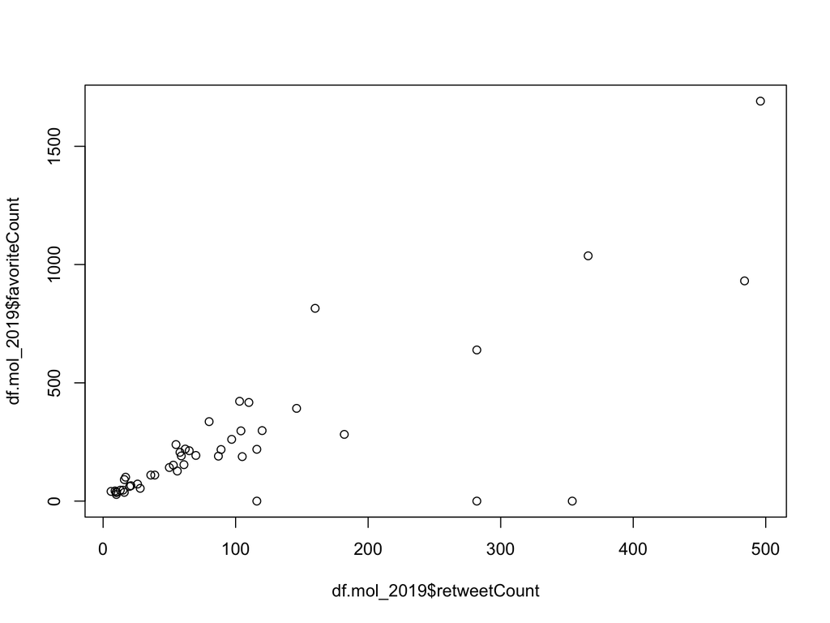

```r
plot(df.mol_2019$retweetCount, df.mol_2019$favoriteCount)
```

## The “outlier”?

```r
df.mol_2019[which.max(df.mol_2019$favoriteCount), 'text']
```

```
## [1] "The PM must finally rule out a no deal Brexit once and for all to avoid catastrophic consequences for Londoners and… https://t.co/kxvf1r7LJy"
```

## Tweets by location

Search:

- most retweeted tweets –> **sort by `retweetCount`**
- yesterday –> **set date to 8 Jan 2019**
- in London –> **???**
- about: …

Solution: geo coordinates.

## Tweets by location

[figure not shown]

**(51.507824, -0.127654)**

We also add a radius around that point location.

## Tweets by location

```r
tweets_in_london = searchTwitter(searchString = ' '
                         , since = '2019-01-01'
                         , n = 100
                         , geocode='51.507824,-0.127654,15km'
                         )
head(tweets_in_london)
```

```
## [[1]]
## [1] "niamhethandarcy: RT @matthewsyed: British tennis was amateurish, parochial and about the old boy network. Then the Murray family arrived and drove a coach a…"
##
## [[2]]
## [1] "gtrlucie: RT @aveirjapan: https://t.co/VI1jTcLU2t"
##
## [[3]]
## [1] "preshn9: RT @donnyc1975: @JolyonMaugham @damocrat With one party you will have disaster capitalism - with the other you’ll have disaster socialism .…"
##
## [[4]]
## [1] "flawlessftmalik: RT @esnysophie: LIAM HAS BEEN NOMINATED FOR A BRIT. DO NOT LET HIM DOWN GUYS. THIS MAN GAVE US A FREE CONCERT, MET ALL OF HIS FANS OUTSIDE…"
##
## [[5]]
## [1] "FrauVonHerzL: RT @streetartmagic: Zabou - French Street Artist - Paris (F) - 02/2015 https://t.co/QihGPaD8y4"
##
## [[6]]
## [1] "Ege2503: RT @NZ_Bazou: T’es en couple? — Célibataire depuis 1956 https://t.co/VK3nU3XW1L"
```

## Tweets by language

Common problem:

- you search for a keyword
- but it’s in multiple languages

```r
?searchTwitter
```

`lang`:

> If not NULL, restricts tweets to the given language, given by an ISO 639-1 code

## Tweets by language

ISO 639-1 language codes: https://www.loc.gov/standards/iso639-2/php/code_list.php

```r
searchTwitter(searchString = '#metoo'
                         , since = '2019-01-01'
                         , n = 5
                         , lang = 'en'
                         )
```

```
## [[1]]
## [1] "LeadingWPassion: How to Tap Into Your Greatest Leadership Potential: https://t.co/z7ChRwi9xS\n#feminism #metoo"
##
## [[2]]
## [1] "Tudumonstu: RT @RoshanKrRai: So #RajkumarHirani , the biggest image laundry is now himself stained. \n\nLet's see who makes a movie on him making him loo…"
##
## [[3]]
## [1] "metoozoo: #MeToo Merch - YellowMaps Beaver Island MI topo map, 1:100000 Scale, 30 X 60 Minute, Historical, 1984, Updated 1989… https://t.co/DsklJ4FZrA"
##
## [[4]]
## [1] "gulfkannadiga: RT @timesofindia: #MeToo movement: Filmmaker #RajkummarHirani's Assistant Director  of #Sanju accuses him of sexual harassment \n\nvia @etime…"
##
## [[5]]
## [1] "WeForNews: Rajkumar Hirani accused of sexual assault during making of Sanju\n\n#MeToo #MeTooMovement #RajuBhai #RajKumarHirani… https://t.co/rw3zpitdUd"
```

## Tweets by language

```r
searchTwitter(searchString = '#metoo'
                         , since = '2019-01-01'
                         , n = 5
                         , lang = 'es'
                         )
```

```
## [[1]]
## [1] "Mirbia3: RT @la_patilla: Los aspirantes demócratas a la Casa Blanca bajo examen del #MeToo https://t.co/DYj2t5OFcS       .     ."
##
## [[2]]
## [1] "77diegoleon: RT @NunkMasKKs: Las del hashtag #JuntoAActricesArgentinas que se llenan la boca hablando de sororidad, son las mismas que compartían actos…"
##
## [[3]]
## [1] "Marlyndreams: RT @NunkMasKKs: Las del hashtag #JuntoAActricesArgentinas que se llenan la boca hablando de sororidad, son las mismas que compartían actos…"
##
## [[4]]
## [1] "lucaluna2015: RT @NunkMasKKs: Las del hashtag #JuntoAActricesArgentinas que se llenan la boca hablando de sororidad, son las mismas que compartían actos…"
##
## [[5]]
## [1] "Remanso4: RT @NunkMasKKs: Las Griseldas Sicilianis de la vida dijeron: \"A las pibas se les cree\", cuando Thelma Fardin denunció a Darthés.\n\nAhora, ot…"
```

## Combined search queries

**Example:** Burglaries since Christmas?

```r
combined_query_1 = searchTwitter(searchString = 'burgled'
              , since = '2018-12-24'
              #, until = '2019-01-07'
              , n = 100
              , lang = 'en'
              )
head(combined_query_1)
```

```
## [[1]]
## [1] "RobertCongreve: RT @K9Finn: Riding school charity for the disabled were burgled and all their equipment stolen. Anyone have any spare kit they can donate t…"
##
## [[2]]
## [1] "jwoodford74: RT @paul_samouelle: Anybody seen this piece of scum. He burgled my children's nursery in Wanstead 1am on the 11th of Jan. https://t.co/ZSfj…"
##
## [[3]]
## [1] "RobertAlanWint2: RT @K9Finn: Riding school charity for the disabled were burgled and all their equipment stolen. Anyone have any spare kit they can donate t…"
##
## [[4]]
## [1] "PhoebeBellend: can’t believe my gaffs been burgled haha what a day"
##
## [[5]]
## [1] "RobertAlanWint2: RT @neenaw: My mother (72) was burgled last week. They took her watch, which is nearly 40 years old and was a present from my father, who d…"
##
## [[6]]
## [1] "oconnke: RT @RichardWellings: When ordinary members of the public get robbed or burgled the police often don't even bother to turn up. How different…"
```

## Combined search queries

**Example:** Reactions to the Soubry issue in two cities?

```r
soubry_london = searchTwitter(searchString = 'soubry'
              , since = '2019-01-01'
              , n = 100
              , lang = 'en'
              , geocode='51.507824,-0.127654,15km'
              )
head(soubry_london, 2)
```

```
## [[1]]
## [1] "baneman21: RT @Frankhaviland: If calling Anna Soubry a ‘Nazi’ is a crime, we’re gonna need another 17.4 million prison places. #JamesGoddard https://t…"
##
## [[2]]
## [1] "journopoly: @Anna_Soubry @carolecadwalla The citizens see past the pretence of Parliamentarians and Parliawomentarians working… https://t.co/OAflmxtNJd"
```

```r
soubry_manchester = searchTwitter(searchString = 'soubry'
              , since = '2019-01-01'
              , n = 100
              , lang = 'en'
              , geocode='53.480874,-2.242588,15km'
              )
head(soubry_manchester, 2)
```

```
## [[1]]
## [1] "jameslynn38: RT @StephenWadswor2: Absolutely shameful. Crocodile tears, then when the direct question of her party's responsibility for this situation i…"
##
## [[2]]
## [1] "JamesIsherwoo15: BBC News - Brexit failure a catastrophic breach of trust, says May https://t.co/juUQrAxmu3. Grieve and Soubry give… https://t.co/0cGz7hqEbS"
```

## Combined search queries

*Your turn: what does this search do?*

```r
searchTwitter(searchString = '@Anna_Soubry + nazi'
              , since = '2019-01-01'
              , n = 5
              , lang = 'en'
              , resultType = 'popular'
              )
```

## Combined search queries

*Your turn: what does this search do?*

```r
searchTwitter(searchString = '@Anna_Soubry + nazi'
              , since = '2019-01-01'
              , n = 5
              , lang = 'en'
              , resultType = 'popular'
              )
```

```
## [[1]]
## [1] "SuzanneEvans1: And after screaming blue murder when @Anna_Soubry is called a ‘Nazi’, tonight @bbcnews is...silent. https://t.co/UrQm6GpuD2"
##
## [[2]]
## [1] "BBCNormanS: Is this what its come to ...? @Anna_Soubry faces \"nazi\" taunts..... https://t.co/NHNMULtbEK"
##
## [[3]]
## [1] "BBCPolitics: \"This is astonishing. This is what has happened to our country\" \n\nConservative MP @Anna_Soubry briefly stops live B… https://t.co/c0hZ22swyl"
##
## [[4]]
## [1] "AngelaRayner: What has our Country come to when watching @BBCNews all you can hear is chants from protesters calling @Anna_Soubry… https://t.co/rCjXUS8ksR"
##
## [[5]]
## [1] "davidkurten: I agree with @Anna_Soubry - it's wrong to call someone a Nazi with no justification. I wonder if her mate… https://t.co/x8dXYZUHnY"
```

## Get Twitter trends

```r
?getTrends
```

`getTrends(woeid, exclude=NULL, ...)`

> woeid: A numerical identification code describing a location, a Yahoo! Where On Earth ID

–> Cross-reference WOEID against search string/address [here](http://woeid.rosselliot.co.nz/lookup/san%20francisco)

## getTrends…

San Francisco, California –> `woied = 2487956`

```r
trends_sf = getTrends(woeid = 2487956)

head(trends_sf)
```

```
##          name                                           url
## 1     Cowboys           http://twitter.com/search?q=Cowboys
## 2   #dalvslar       http://twitter.com/search?q=%23dalvslar
## 3 CJ Anderson http://twitter.com/search?q=%22CJ+Anderson%22
## 4        Rams              http://twitter.com/search?q=Rams
## 5    #INDvsKC        http://twitter.com/search?q=%23INDvsKC
## 6       Colts             http://twitter.com/search?q=Colts
##               query   woeid
## 1           Cowboys 2487956
## 2       %23dalvslar 2487956
## 3 %22CJ+Anderson%22 2487956
## 4              Rams 2487956
## 5        %23INDvsKC 2487956
## 6             Colts 2487956
```

## Additional stuff…

**Twitter API/twitteR package**

- URLs
- followers
- user info
- …

**Twitter Search API vs Twitter Stream API**

- query quality
- result quantity

### Problems with Twitter/YouTube data?

## Some issues:

- Sample representativeness
- Location accuracy
- Location availability
- Sampling through API

## Case 2: Youtube’s API

[figure not shown]

## Getting access

Basic steps

1. Google account
2. Login to Google Developers Console
3. Create project/app
4. Obtain access credentials

Tutorial [here](https://help.aolonnetwork.com/hc/en-us/articles/218079623-How-to-Create-Your-YouTube-API-Credentials)

## The `tuber` package

```r
library(tuber)
```

- Documentation: pdf
- Source code: [GitHub](https://github.com/soodoku/tuber)
- Demos: [developer’s tutorial](http://soodoku.github.io/tuber/), [basic first steps](https://towardsdatascience.com/what-is-api-and-how-to-use-youtube-api-65525744f520) + next week’s tutorial

## Authentication

```r
client_secret = 'rwHJJDPf_xdvIWmQ4TL00HKz'
client_id = '625618111946-mf44nomvi5m9ot668b59k7koq122jmaa.apps.googleusercontent.com'

yt_oauth(app_id = client_id, app_secret = client_secret, token='')
```

## Meta data per video

First step: get the video ID.

[figure not shown]

## Meta data per video

Get the “meta” stats for this video:

```r
video_identifier = '_H-UnmiMc3s'

video_stats = get_stats(video_id = video_identifier)
as.data.frame(video_stats)
```

```
##            id viewCount likeCount dislikeCount favoriteCount commentCount
## 1 _H-UnmiMc3s   1248936     41311         1041             0         3921
```

## Detailed data per video

Want more depth of detail?

```r
video_details = get_video_details(video_id = video_identifier)
video_details
```

```
## $kind
## [1] "youtube#videoListResponse"
##
## $etag
## [1] "\"XpPGQXPnxQJhLgs6enD_n8JR4Qk/jSWIMSiXSwvh-NUIY6h8ErCkZhw\""
##
## $pageInfo
## $pageInfo$totalResults
## [1] 1
##
## $pageInfo$resultsPerPage
## [1] 1
##
##
## $items
## $items[[1]]
## $items[[1]]$kind
## [1] "youtube#video"
##
## $items[[1]]$etag
## [1] "\"XpPGQXPnxQJhLgs6enD_n8JR4Qk/QXED6LnSMrVngC72qDrXUvb2znc\""
##
## $items[[1]]$id
## [1] "_H-UnmiMc3s"
##
## $items[[1]]$snippet
## $items[[1]]$snippet$publishedAt
## [1] "2018-12-14T14:37:30.000Z"
##
## $items[[1]]$snippet$channelId
## [1] "UCtinbF-Q-fVthA0qrFQTgXQ"
##
## $items[[1]]$snippet$title
## [1] "Never Ride an ELECTRIC SCOOTER in the Rain"
##
## $items[[1]]$snippet$description
## [1] "thank you for such an amazing visit Poland.  looking forward to coming back to Warsaw.\n\nmusic by; https://youtube.com/joakimkarud\nlast song by; http://smarturl.it/venturamusix"
##
## $items[[1]]$snippet$thumbnails
## $items[[1]]$snippet$thumbnails$default
```

[output cut: 76 more lines]

```
## [1] "22"
##
## $items[[1]]$snippet$liveBroadcastContent
## [1] "none"
##
## $items[[1]]$snippet$localized
## $items[[1]]$snippet$localized$title
## [1] "Never Ride an ELECTRIC SCOOTER in the Rain"
##
## $items[[1]]$snippet$localized$description
## [1] "thank you for such an amazing visit Poland.  looking forward to coming back to Warsaw.\n\nmusic by; https://youtube.com/joakimkarud\nlast song by; http://smarturl.it/venturamusix"
##
##
## $items[[1]]$snippet$defaultAudioLanguage
## [1] "en"
```

## Detailed data per video

A closer look:

`items[[1]]$snippet$thumbnails$high$url`

https://i.ytimg.com/vi/_H-UnmiMc3s/hqdefault.jpg

Think of:

- thumbnails for propaganda
- clickbait understanding

## Comments per video

Comments made below the video:

New video: [Introducing the Numberphile Podcast](https://www.youtube.com/watch?v=0GzhWPj4-cw)

```r
video_identifier_2 = '0GzhWPj4-cw'

video_comments = get_all_comments(video_id = video_identifier_2)
names(video_comments)
```

```
##  [1] "authorDisplayName"     "authorProfileImageUrl"
##  [3] "authorChannelUrl"      "authorChannelId.value"
##  [5] "videoId"               "textDisplay"
##  [7] "textOriginal"          "canRate"
##  [9] "viewerRating"          "likeCount"
## [11] "publishedAt"           "updatedAt"
## [13] "id"                    "parentId"
## [15] "moderationStatus"
```

## Comments per video

A closer look:

```r
head(video_comments)
```

```
##   authorDisplayName
## 1         For Phone
## 2      Martin Wujet
## 3        DarknessFX
## 4       vignesh war
## 5       Knives Town
## 6   Leonardo Castro
##                                                                                         authorProfileImageUrl
## 1 https://yt3.ggpht.com/-zzteRRx5IS4/AAAAAAAAAAI/AAAAAAAAAAA/n5vSdvluSPk/s28-c-k-no-mo-rj-c0xffffff/photo.jpg
## 2 https://yt3.ggpht.com/-M-LYAfoZxEw/AAAAAAAAAAI/AAAAAAAAAAA/YSgUM7jnmJ0/s28-c-k-no-mo-rj-c0xffffff/photo.jpg
## 3 https://yt3.ggpht.com/-LCk4tCJGpyw/AAAAAAAAAAI/AAAAAAAAAAA/i9d94vyWM8o/s28-c-k-no-mo-rj-c0xffffff/photo.jpg
## 4 https://yt3.ggpht.com/-Vp8GoRNPR3s/AAAAAAAAAAI/AAAAAAAAAAA/qwchRgCi_b0/s28-c-k-no-mo-rj-c0xffffff/photo.jpg
## 5 https://yt3.ggpht.com/-xOvjHZvnw2c/AAAAAAAAAAI/AAAAAAAAAAA/BFjyPiiydRU/s28-c-k-no-mo-rj-c0xffffff/photo.jpg
## 6 https://yt3.ggpht.com/-2Vp8jMULXk8/AAAAAAAAAAI/AAAAAAAAAAA/oH74EQ4onzw/s28-c-k-no-mo-rj-c0xffffff/photo.jpg
##                                          authorChannelUrl
```

[output cut: 48 more lines]

## Transcript (captions)

YouTube transcrips yet untapped source!

Few exceptions:

- [Identifying the sentiment styles of YouTube’s vloggers](https://arxiv.org/ftp/arxiv/papers/1808/1808.09722.pdf)
- [Social Media Sellout: The Increasing Role of Product Promotion on YouTube](https://journals.sagepub.com/doi/10.1177/2056305118786720)

## Transcript (captions)

Tricky to get transcripts.

- uploader needs to provide proper transcript (high quality, low availibility)
- workaround approach (moderate/low quality, high availibility)

```r
?get_captions
?list_caption_tracks
```

## Meta data per channel

First: identify the channel ID.

[figure not shown]

## Meta data per channel

```r
channel_identifier = 'UCLXo7UDZvByw2ixzpQCufnA'
channel_stats = get_channel_stats(channel_id = channel_identifier)
```

```
## Channel Title: Vox
## No. of Views: 1209094639
## No. of Subscribers: 5426703
## No. of Videos: 946
```

```r
channel_stats
```

```
## $kind
## [1] "youtube#channel"
##
## $etag
## [1] "\"XpPGQXPnxQJhLgs6enD_n8JR4Qk/u5LBm16TDKiRba0uYloNu5kz1aQ\""
##
## $id
## [1] "UCLXo7UDZvByw2ixzpQCufnA"
##
## $snippet
## $snippet$title
## [1] "Vox"
##
## $snippet$description
## [1] "Vox helps you cut through the noise and understand what's driving events in the headlines and in our lives.\n\nVox Video is Joe Posner, Mona Lalwani, Valerie Lapinski, Joss Fong, Estelle Caswell, Johnny Harris, Phil Edwards, Carlos Waters, Gina Barton, Liz Scheltens, Christophe Haubursin, Ca…
##
## $snippet$customUrl
## [1] "voxdotcom"
##
## $snippet$publishedAt
## [1] "2014-03-04T20:30:22.000Z"
##
## $snippet$thumbnails
## $snippet$thumbnails$default
## $snippet$thumbnails$default$url
## [1] "https://yt3.ggpht.com/a-/AAuE7mBlnA9KlCyHqQzT6DIpVGM3e0_gSv3nKdwgsA=s88-mo-c-c0xffffffff-rj-k-no"
##
## $snippet$thumbnails$default$width
## [1] 88
##
## $snippet$thumbnails$default$height
## [1] 88
##
##
## $snippet$thumbnails$medium
## $snippet$thumbnails$medium$url
## [1] "https://yt3.ggpht.com/a-/AAuE7mBlnA9KlCyHqQzT6DIpVGM3e0_gSv3nKdwgsA=s240-mo-c-c0xffffffff-rj-k-no"
##
## $snippet$thumbnails$medium$width
## [1] 240
```

[output cut: 29 more lines]

```
## $statistics
## $statistics$viewCount
## [1] "1209094639"
##
## $statistics$commentCount
## [1] "0"
##
## $statistics$subscriberCount
## [1] "5426703"
##
## $statistics$hiddenSubscriberCount
## [1] FALSE
##
## $statistics$videoCount
## [1] "946"
```

## Meta data per channel

Some statistics per channel:

```r
channel_stats$statistics
```

```
## $viewCount
## [1] "1209094639"
##
## $commentCount
## [1] "0"
##
## $subscriberCount
## [1] "5426703"
##
## $hiddenSubscriberCount
## [1] FALSE
##
## $videoCount
## [1] "946"
```

## Activity data per channel

New channel (smaller): JSNation

```r
channel_identifier_2 = 'UCQM428Hwrvxla8DCgjGONSQ'
channel_activity = list_channel_activities(filter = c(channel_id = channel_identifier_2),
                                           max_results = 50)
names(channel_activity)
```

```
##  [1] "publishedAt"                "channelId"
##  [3] "title"                      "description"
##  [5] "thumbnails.default.url"     "thumbnails.default.width"
##  [7] "thumbnails.default.height"  "thumbnails.medium.url"
##  [9] "thumbnails.medium.width"    "thumbnails.medium.height"
## [11] "thumbnails.high.url"        "thumbnails.high.width"
## [13] "thumbnails.high.height"     "thumbnails.standard.url"
## [15] "thumbnails.standard.width"  "thumbnails.standard.height"
## [17] "thumbnails.maxres.url"      "thumbnails.maxres.width"
## [19] "thumbnails.maxres.height"   "channelTitle"
## [21] "type"                       "groupId"
```

## Activity data per channel

```r
head(channel_activity)
```

```
##                publishedAt                channelId
## 1 2018-12-10T09:58:22.000Z UCQM428Hwrvxla8DCgjGONSQ
## 2 2018-12-13T16:07:13.000Z UCQM428Hwrvxla8DCgjGONSQ
## 3 2018-12-10T09:57:31.000Z UCQM428Hwrvxla8DCgjGONSQ
## 4 2018-12-13T16:07:05.000Z UCQM428Hwrvxla8DCgjGONSQ
## 5 2018-12-10T09:54:19.000Z UCQM428Hwrvxla8DCgjGONSQ
## 6 2018-12-13T16:06:52.000Z UCQM428Hwrvxla8DCgjGONSQ
##                                                                     title
## 1 How to refactor JavaScript with JavaScript on a massive scale – Kersjes
## 2 How to refactor JavaScript with JavaScript on a massive scale – Kersjes
## 3           Creating IoT Applications with Web Bluetooth – Martin Woolley
## 4           Creating IoT Applications with Web Bluetooth – Martin Woolley
## 5                The impostor syndrome aka I'm a fraud – Claudio Semeraro
## 6                The impostor syndrome aka I'm a fraud – Claudio Semeraro
##                                                                                                                                                                                                                                                                                                          …
```

[output cut: 76 more lines]

## Video stats per channel

Stats for all videos in a channel:

```r
all_video_stats = get_all_channel_video_stats(channel_id = channel_identifier_2)
names(all_video_stats)
```

[output not shown]

## Video stats per channel

```r
head(all_video_stats)
```

```
##            id
## 1 _4nrh6mTt4E
## 2 _iIxC8ziZNM
## 3 -BGxJn3c7NA
## 4 -CGpVrydTyg
## 5 0t9FERJRShQ
## 6 1eH9-cLMXQg
##                                                                              title
## 1                                   Amsterdam JSNation Conference 2018 Live stream
## 2                                Smart Contracts in JavaScript - Mikhail Kuznetcov
## 3                         TypeScript Ruined My Life (In a Good Way) - Andy Mockler
## 4 SonarJS: How To Build a Static Code Analyzer - Elena Vilchik & Carlo Bottiglieri
## 5                                         The dark ages of IoT - Sebastian Golasch
## 6                       In the Ocean of Angular Web Applications - Yaprak Ayazoglu
##           publication_date viewCount likeCount dislikeCount favoriteCount
## 1 2018-06-01T16:58:23.000Z      2886        61            0             0
## 2 2018-04-08T17:11:16.000Z       351         8            0             0
## 3 2018-06-08T14:34:50.000Z       332         1            1             0
## 4 2017-09-20T20:30:04.000Z       532         7            0             0
## 5 2018-06-08T14:31:14.000Z        60         2            0             0
## 6 2018-06-17T17:42:55.000Z       133         4            0             0
##   commentCount                                         url
## 1            7 https://www.youtube.com/watch?v=_4nrh6mTt4E
## 2            0 https://www.youtube.com/watch?v=_iIxC8ziZNM
## 3            2 https://www.youtube.com/watch?v=-BGxJn3c7NA
## 4            0 https://www.youtube.com/watch?v=-CGpVrydTyg
## 5            0 https://www.youtube.com/watch?v=0t9FERJRShQ
## 6            0 https://www.youtube.com/watch?v=1eH9-cLMXQg
```

## Additional queries

### Problems with Twitter/YouTube data?

## Some issues:

- Sample representativeness
- Location accuracy
- Location availability
- ~Sampling through API~
- Transcript quality
- Real representations (filtered)
- Censored?

## Crime data interfaces

- [police.uk](https://data.police.uk/)
- [R package “crimedata”](https://cran.r-project.org/web/packages/crimedata/crimedata.pdf)

## police.uk as data repository

### Public database of “open police data”

[figure not shown]

## police.uk as data repository

### API?

[figure not shown]

## police.uk as data repository

Using the API:

- different method
- calls direct from the browser
- no R implementation

> The API is implemented as a standard JSON web service using HTTP GET and POST requests. Full request and response examples are provided in the documentation.

## police.uk as data repository

[“Crimes at location”](https://data.police.uk/docs/method/crimes-at-location/)

Search query example:

```html
https://data.police.uk/api/crimes-at-location?date=2017-08&location_id=884227
```

[figure not shown]

## police.uk as data repository

[figure not shown]

## `crimedata` package

```r
library(crimedata)
```

## `crimedata` package

Aim:

> Gives convenient access to publicly available police-recorded open crime data from large cities in the United States that are included in the Crime Open Database

[Open Crime Database](https://osf.io/zyaqn/)

## `crimedata` package

Which data are available?

```r
list_crime_data(quiet = FALSE)
```

```
## # A tibble: 11 x 2
##    city           years
##    <chr>          <chr>
##  1 all cities     2007 to 2017
##  2 Chicago        2007 to 2017
##  3 Detroit        2009 to 2017
##  4 Fort Worth     2007 to 2017
##  5 Kansas City    2009 to 2017
##  6 Los Angeles    2010 to 2017
##  7 Louisville     2009 to 2017
##  8 New York       2007 to 2017
##  9 San Francisco  2007 to 2017
## 10 Tucson         2009 to 2017
## 11 Virginia Beach 2013 to 2017
```

## `crimedata` package

Getting data:

```r
crime_data_ny_2017 = get_crime_data(years = 2017
                            , cities = c("New York"))
```

```
## Using cached URLs to get data from server. These URLs rarely change and this is almost certainly safe.
```

```r
names(crime_data_ny_2017)
```

```
##  [1] "uid"               "city_name"         "offense_code"
##  [4] "offense_type"      "offense_group"     "offense_against"
##  [7] "date_single"       "date_start"        "date_end"
## [10] "longitude"         "latitude"          "location_type"
## [13] "location_category" "census_block"
```

```r
head(crime_data_ny_2017)
```

```
## # A tibble: 6 x 14
##      uid city_name offense_code offense_type offense_group offense_against
##    <int> <chr>     <chr>        <chr>        <chr>         <chr>
## 1 1.38e7 New York  90Z          all other o… all other of… other
## 2 1.38e7 New York  22B          non-residen… burglary/bre… property
## 3 1.38e7 New York  13B          simple assa… assault offe… persons
## 4 1.38e7 New York  90Z          all other o… all other of… other
## 5 1.38e7 New York  12A          personal ro… robbery       property
## 6 1.38e7 New York  90Z          all other o… all other of… other
## # ... with 8 more variables: date_single <chr>, date_start <chr>,
## #   date_end <chr>, longitude <dbl>, latitude <dbl>, location_type <chr>,
## #   location_category <chr>, census_block <chr>
```

## `crimedata` package

Multiple cities, multiple years:

```r
crime_data_2010_2015 = get_crime_data(years = 2010:2015
                            , cities = c("Chicago", "Detroit"))
table(crime_data_2010_2015$city_name, crime_data_2010_2015$offense_against)
```

```
##
##           other persons property society
##   Chicago  1434    4811     9658    2992
##   Detroit   480    1445     4096     492
```

## `crimedata` package

Additional features:

- `nycvehiclethefts`: Dataset containing records of thefts of motor vehicles in New York City from 2014 to 2017
- `homicides15`: Dataset containing records of homicides in nine large US cities in 2015

## APIs: Pros & Cons

**Pro**

- easiy to access
- nicely documentation
- **works even if website changes**

**Cons**

- quota limits ($ $ $)
- under the platforms’ control
- only for few platforms

### Don’t let the data determine your research!

## COOL

But what about:

[figure not shown]

## No APIs

- incels.me
- stormfront
- 4chan
- **APIs are restrictive!**

## … what about:

### Your research question –> no API?

[figure not shown]

Main problem:

**Really ‘juicy’ data of the Internet** vs **APIs**

## “Real” webscraping: basics of a webpage

## Three elements of a webpage

1. Structure
2. Behaviour
3. Style

## Three elements of a webpage

1. Structure
2. Behaviour
   - JavaScript (**!= Java**)
   - user interaction
   - examples: alerts, popups, server-interaction
3. Style

## Three elements of a webpage

1. Structure
2. Behaviour
3. Style
   - CSS (Cascading Style Sheets)
   - formatting, design, responsiveness
   - examples: submit buttons, app interaces

## Three elements of a webpage

1. Structure
   - HTML (hypertext markup language)
   - structured with `<tags>`
   - contains the pure content of the webpage
2. Behaviour
3. Style

## For now: HTML

The very basics of HTML:

**Raw architecture of a webpage**

```html
<!DOCTYPE html>
<html>
<body>

HERE COMES THE VISIBLE PART!!

</body>
</html>
```

*Note:* Every tags `< >` is closed `< />`. Content is contained within the tag.

## HTML basics

Ways to put content in the `<body> ... </body>` tag:

- headings: `<h1>I'm a heading at level 1</>`

[figure not shown]

## Content in the body tag

- paragraphs: `<p>This is a paragraph</p>`

[figure not shown]

## Content in the body tag

- images: `<img src="./img/ucl.jpg">`

[figure not shown]

## Content in the body tag

- links: `<a href="https://www.ucl.ac.uk/">Click here to go to UCL's website</a></a>`

[figure not shown]

## Content in the body tag

- tables

```html
<table>
  <tr>
    <th>Departments</th>
    <th>Location</th>
  </tr>
  <tr>
    <td>Dept. of Security and Crime Science</td>
    <td>Division of Psychology and Language Sciences</td>
  </tr>
  <tr>
    <td>35 Tavistock Square</td>
    <td>26 Bedford Way</td>
  </tr>
</table>
```

## Html `<table>...</table>`

[figure not shown]

## Content in the body tag

- lists

```html
<ul>
  <li>Terrorism</li>
  <li>Cyber Crime</li>
  <li>Data Science</li>
</ul>
```

[figure not shown]

## HTML basics

Elements (can) have IDs:

```html
<p id='paragraph1'>This is a paragraph</p>
<img id='ucl_image' src="./img/ucl.jpg">
```

Same for tables, links, etc.

Every element can have an ID.

You need unique IDs! Two elements cannot have the same ID.

## HTML basics

Common elements (can) have CLASSES:

```html
<p id="paragraph1" class="paragraph_class">I am the first paragraph</p>
<p class="paragraph_class">I am the second paragraph</p>
<p class="paragraph_class">I am the third paragraph</p>
```

Multiple elements can have the same class.

### Now what?

## Web scraping logic

If all webpages are built in this structure…

… then we could access this structure programmatically.

## But where do I find that structure?

Is it just “there”?

**YES!!**

## How to see the html structure?

[figure not shown]

## Example 1: Missing persons

[figure not shown]

## Example 1: Missing persons

[figure not shown]

## Example 2: FBI most wanted

[figure not shown]

## Webscraping in a nutshell

1. understand the structure of a webpage
2. exploit that structure for web-scraping

## RECAP

- **Always: problem first, never the method first!**
- **Method follows problem!**
- APIs give you structured access
- R packages `twitteR` and `tuber`
- HTML structure key to ‘real’ webscraping

## Outlook

**Next week**

- Webscraping on the html structure
- Tutorial: APIs + webscraping in R

**Homework**

- Getting access to YouTube and Twitter API.